# Risk Factor Analysis

## Outcome Variable

**Outcome Variable:** ever_stunted

## Predictor Variables

**Intervention Variable:** gagebrth

**Adjustment Set:**

- arm
- sex
- W_mage
- meducyrs
- feducyrs
- hhwealth_quart
- W_nrooms
- W_nchldlt5
- brthmon
- W_parity
- impsan
- delta_W_mage
- delta_meducyrs
- delta_feducyrs
- delta_hhwealth_quart
- delta_W_nrooms
- delta_W_nchldlt5
- delta_brthmon
- delta_W_parity
- delta_impsan

## Stratifying Variables

The analysis was stratified on these variable(s):

- agecat
- studyid
- country

## Data Summary

| agecat | studyid | country | gagebrth | ever_stunted | n_cell | n |
| --- | --- | --- | --- | --- | --- | --- |
| 0-24 months (no birth st.) | ki1000108-CMC-V-BCS-2002 | INDIA | Full or late term | 0 | 18 | 278 |
| 0-24 months (no birth st.) | ki1000108-CMC-V-BCS-2002 | INDIA | Full or late term | 1 | 164 | 278 |
| 0-24 months (no birth st.) | ki1000108-CMC-V-BCS-2002 | INDIA | Preterm | 0 | 3 | 278 |
| 0-24 months (no birth st.) | ki1000108-CMC-V-BCS-2002 | INDIA | Preterm | 1 | 30 | 278 |
| 0-24 months (no birth st.) | ki1000108-CMC-V-BCS-2002 | INDIA | Early term | 0 | 7 | 278 |
| 0-24 months (no birth st.) | ki1000108-CMC-V-BCS-2002 | INDIA | Early term | 1 | 56 | 278 |
| 0-24 months (no birth st.) | ki1000108-IRC | INDIA | Full or late term | 0 | 95 | 341 |
| 0-24 months (no birth st.) | ki1000108-IRC | INDIA | Full or late term | 1 | 126 | 341 |
| 0-24 months (no birth st.) | ki1000108-IRC | INDIA | Preterm | 0 | 9 | 341 |
| 0-24 months (no birth st.) | ki1000108-IRC | INDIA | Preterm | 1 | 23 | 341 |
| 0-24 months (no birth st.) | ki1000108-IRC | INDIA | Early term | 0 | 34 | 341 |
| 0-24 months (no birth st.) | ki1000108-IRC | INDIA | Early term | 1 | 54 | 341 |
| 0-24 months (no birth st.) | ki1000109-EE | PAKISTAN | Full or late term | 0 | 6 | 498 |
| 0-24 months (no birth st.) | ki1000109-EE | PAKISTAN | Full or late term | 1 | 30 | 498 |
| 0-24 months (no birth st.) | ki1000109-EE | PAKISTAN | Preterm | 0 | 28 | 498 |
| 0-24 months (no birth st.) | ki1000109-EE | PAKISTAN | Preterm | 1 | 292 | 498 |
| 0-24 months (no birth st.) | ki1000109-EE | PAKISTAN | Early term | 0 | 32 | 498 |
| 0-24 months (no birth st.) | ki1000109-EE | PAKISTAN | Early term | 1 | 110 | 498 |
| 0-24 months (no birth st.) | ki1000304b-SAS-CompFeed | INDIA | Full or late term | 0 | 8 | 1081 |
| 0-24 months (no birth st.) | ki1000304b-SAS-CompFeed | INDIA | Full or late term | 1 | 16 | 1081 |
| 0-24 months (no birth st.) | ki1000304b-SAS-CompFeed | INDIA | Preterm | 0 | 422 | 1081 |
| 0-24 months (no birth st.) | ki1000304b-SAS-CompFeed | INDIA | Preterm | 1 | 550 | 1081 |
| 0-24 months (no birth st.) | ki1000304b-SAS-CompFeed | INDIA | Early term | 0 | 35 | 1081 |
| 0-24 months (no birth st.) | ki1000304b-SAS-CompFeed | INDIA | Early term | 1 | 50 | 1081 |
| 0-24 months (no birth st.) | ki1017093c-NIH-Crypto | BANGLADESH | Full or late term | 0 | 105 | 653 |
| 0-24 months (no birth st.) | ki1017093c-NIH-Crypto | BANGLADESH | Full or late term | 1 | 51 | 653 |
| 0-24 months (no birth st.) | ki1017093c-NIH-Crypto | BANGLADESH | Preterm | 0 | 110 | 653 |
| 0-24 months (no birth st.) | ki1017093c-NIH-Crypto | BANGLADESH | Preterm | 1 | 89 | 653 |
| 0-24 months (no birth st.) | ki1017093c-NIH-Crypto | BANGLADESH | Early term | 0 | 181 | 653 |
| 0-24 months (no birth st.) | ki1017093c-NIH-Crypto | BANGLADESH | Early term | 1 | 117 | 653 |

[output cut: 186 more lines]

The following strata were considered:

- agecat: 0-24 months (no birth st.), studyid: ki1000108-CMC-V-BCS-2002, country: INDIA
- agecat: 0-24 months (no birth st.), studyid: ki1000108-IRC, country: INDIA
- agecat: 0-24 months (no birth st.), studyid: ki1000109-EE, country: PAKISTAN
- agecat: 0-24 months (no birth st.), studyid: ki1000304b-SAS-CompFeed, country: INDIA
- agecat: 0-24 months (no birth st.), studyid: ki1017093c-NIH-Crypto, country: BANGLADESH
- agecat: 0-24 months (no birth st.), studyid: ki1066203-TanzaniaChild2, country: TANZANIA, UNITED REPUBLIC OF
- agecat: 0-24 months (no birth st.), studyid: ki1101329-Keneba, country: GAMBIA
- agecat: 0-24 months (no birth st.), studyid: ki1119695-PROBIT, country: BELARUS
- agecat: 0-24 months (no birth st.), studyid: ki1135781-COHORTS, country: GUATEMALA
- agecat: 0-24 months (no birth st.), studyid: ki1135781-COHORTS, country: INDIA
- agecat: 0-24 months (no birth st.), studyid: ki1135781-COHORTS, country: PHILIPPINES
- agecat: 0-24 months (no birth st.), studyid: kiGH5241-JiVitA-3, country: BANGLADESH
- agecat: 0-6 months (no birth st.), studyid: ki1000108-CMC-V-BCS-2002, country: INDIA
- agecat: 0-6 months (no birth st.), studyid: ki1000108-IRC, country: INDIA
- agecat: 0-6 months (no birth st.), studyid: ki1000109-EE, country: PAKISTAN
- agecat: 0-6 months (no birth st.), studyid: ki1000304b-SAS-CompFeed, country: INDIA
- agecat: 0-6 months (no birth st.), studyid: ki1017093c-NIH-Crypto, country: BANGLADESH
- agecat: 0-6 months (no birth st.), studyid: ki1066203-TanzaniaChild2, country: TANZANIA, UNITED REPUBLIC OF
- agecat: 0-6 months (no birth st.), studyid: ki1101329-Keneba, country: GAMBIA
- agecat: 0-6 months (no birth st.), studyid: ki1119695-PROBIT, country: BELARUS
- agecat: 0-6 months (no birth st.), studyid: ki1135781-COHORTS, country: GUATEMALA
- agecat: 0-6 months (no birth st.), studyid: ki1135781-COHORTS, country: INDIA
- agecat: 0-6 months (no birth st.), studyid: ki1135781-COHORTS, country: PHILIPPINES
- agecat: 0-6 months (no birth st.), studyid: kiGH5241-JiVitA-3, country: BANGLADESH
- agecat: 6-24 months, studyid: ki1000108-CMC-V-BCS-2002, country: INDIA
- agecat: 6-24 months, studyid: ki1000108-IRC, country: INDIA
- agecat: 6-24 months, studyid: ki1000109-EE, country: PAKISTAN
- agecat: 6-24 months, studyid: ki1000304b-SAS-CompFeed, country: INDIA
- agecat: 6-24 months, studyid: ki1017093c-NIH-Crypto, country: BANGLADESH
- agecat: 6-24 months, studyid: ki1066203-TanzaniaChild2, country: TANZANIA, UNITED REPUBLIC OF
- agecat: 6-24 months, studyid: ki1101329-Keneba, country: GAMBIA
- agecat: 6-24 months, studyid: ki1119695-PROBIT, country: BELARUS
- agecat: 6-24 months, studyid: ki1135781-COHORTS, country: GUATEMALA
- agecat: 6-24 months, studyid: ki1135781-COHORTS, country: INDIA
- agecat: 6-24 months, studyid: ki1135781-COHORTS, country: PHILIPPINES
- agecat: 6-24 months, studyid: kiGH5241-JiVitA-3, country: BANGLADESH

### Dropped Strata

Some strata were dropped due to rare outcomes:

- agecat: 0-24 months (no birth st.), studyid: ki1000108-CMC-V-BCS-2002, country: INDIA
- agecat: 0-6 months (no birth st.), studyid: ki1000304b-SAS-CompFeed, country: INDIA
- agecat: 6-24 months, studyid: ki1000108-CMC-V-BCS-2002, country: INDIA

## Methods Detail

We’re interested in the causal parameters $E[Y_a]$ for all values of $a \in \mathcal{A}$. These parameters represent the mean outcome if, possibly contrary to fact, we intervened to set all units to have $A=a$. Under the randomization and positivity assumptions, these are identified by the statistical parameters $\psi_a=E_W[E_{Y|A,W}(Y|A=a,W)]$. In addition, we’re interested in the mean of $Y$, $E[Y]$ under no intervention (the observed mean). We will estimate these parameters by using SuperLearner to fit the relevant likelihood factors – $E_{Y|A,W}(Y|A=a,W)$ and $p(A=a|W)$, and then updating our likelihood fit using a joint TMLE.

For unadjusted analyses ($W=\{\}$), initial likelihoods were estimated using Lrnr_glm to estimate the simple $E(Y|A)$ and Lrnr_mean to estimate $p(A)$. For adjusted analyses, a small library containing Lrnr_glmnet, Lrnr_xgboost, and Lrnr_mean was used.

Having estimated these parameters, we will then use the delta method to estimate relative risks and attributable risks relative to a prespecified baseline level of $A$.

# Results Detail

## Results Plots

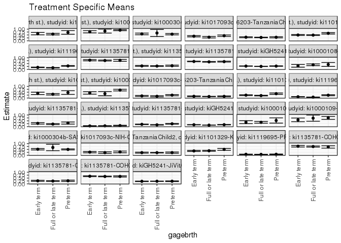

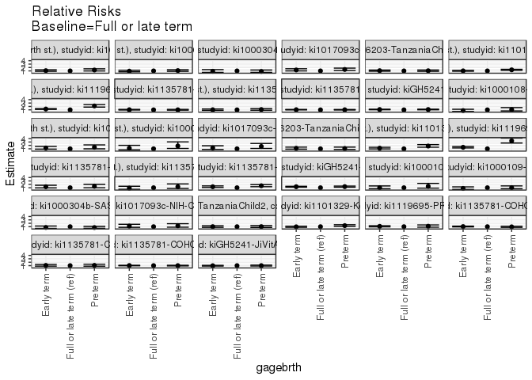

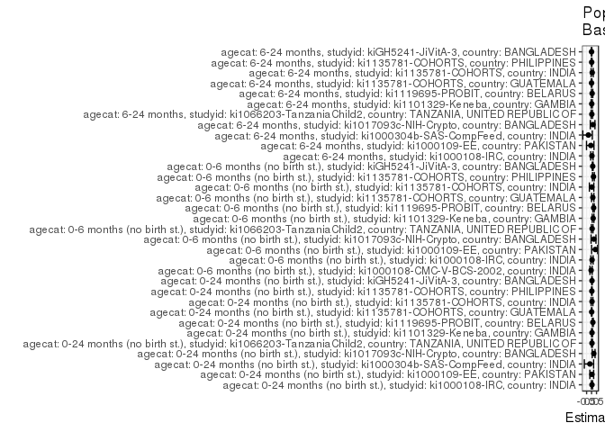

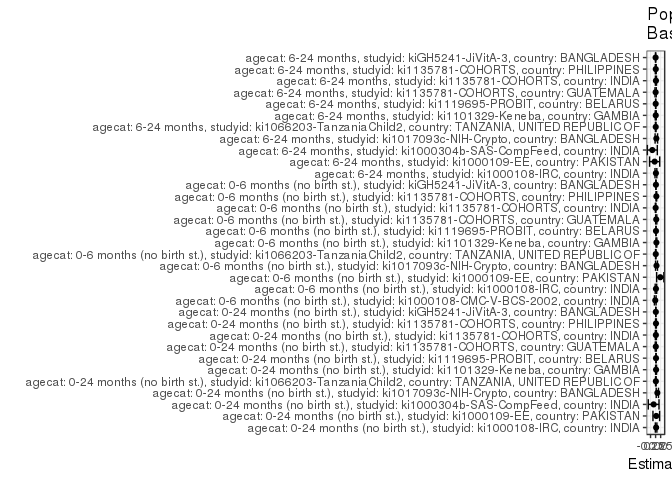

## Results Table

### Parameter: TSM

| agecat | studyid | country | intervention_level | baseline_level | estimate | ci_lower | ci_upper |
| --- | --- | --- | --- | --- | --- | --- | --- |
| 0-24 months (no birth st.) | ki1000108-IRC | INDIA | Full or late term | NA | 0.5701357 | 0.5047709 | 0.6355006 |
| 0-24 months (no birth st.) | ki1000108-IRC | INDIA | Preterm | NA | 0.7187500 | 0.5627423 | 0.8747577 |
| 0-24 months (no birth st.) | ki1000108-IRC | INDIA | Early term | NA | 0.6136364 | 0.5117542 | 0.7155185 |
| 0-24 months (no birth st.) | ki1000109-EE | PAKISTAN | Full or late term | NA | 0.8333333 | 0.6608213 | 1.0058454 |
| 0-24 months (no birth st.) | ki1000109-EE | PAKISTAN | Preterm | NA | 0.9125000 | 0.8686285 | 0.9563715 |
| 0-24 months (no birth st.) | ki1000109-EE | PAKISTAN | Early term | NA | 0.7746479 | 0.6772665 | 0.8720292 |
| 0-24 months (no birth st.) | ki1000304b-SAS-CompFeed | INDIA | Full or late term | NA | 0.6666667 | 0.3663101 | 0.9670232 |
| 0-24 months (no birth st.) | ki1000304b-SAS-CompFeed | INDIA | Preterm | NA | 0.5658436 | 0.5093009 | 0.6223863 |
| 0-24 months (no birth st.) | ki1000304b-SAS-CompFeed | INDIA | Early term | NA | 0.5882353 | 0.5185374 | 0.6579332 |
| 0-24 months (no birth st.) | ki1017093c-NIH-Crypto | BANGLADESH | Full or late term | NA | 0.3058956 | 0.2426802 | 0.3691110 |
| 0-24 months (no birth st.) | ki1017093c-NIH-Crypto | BANGLADESH | Preterm | NA | 0.4350721 | 0.3728886 | 0.4972556 |
| 0-24 months (no birth st.) | ki1017093c-NIH-Crypto | BANGLADESH | Early term | NA | 0.3917257 | 0.3399614 | 0.4434901 |
| 0-24 months (no birth st.) | ki1066203-TanzaniaChild2 | TANZANIA, UNITED REPUBLIC OF | Full or late term | NA | 0.2851537 | 0.2609258 | 0.3093815 |
| 0-24 months (no birth st.) | ki1066203-TanzaniaChild2 | TANZANIA, UNITED REPUBLIC OF | Preterm | NA | 0.2995489 | 0.2508356 | 0.3482623 |
| 0-24 months (no birth st.) | ki1066203-TanzaniaChild2 | TANZANIA, UNITED REPUBLIC OF | Early term | NA | 0.3051172 | 0.2650521 | 0.3451822 |
| 0-24 months (no birth st.) | ki1101329-Keneba | GAMBIA | Full or late term | NA | 0.4859043 | 0.4519388 | 0.5198698 |
| 0-24 months (no birth st.) | ki1101329-Keneba | GAMBIA | Preterm | NA | 0.6401707 | 0.5807266 | 0.6996149 |
| 0-24 months (no birth st.) | ki1101329-Keneba | GAMBIA | Early term | NA | 0.4939470 | 0.4535114 | 0.5343827 |
| 0-24 months (no birth st.) | ki1119695-PROBIT | BELARUS | Full or late term | NA | 0.1389713 | 0.1190431 | 0.1588995 |
| 0-24 months (no birth st.) | ki1119695-PROBIT | BELARUS | Preterm | NA | 0.2974263 | 0.2636832 | 0.3311695 |
| 0-24 months (no birth st.) | ki1119695-PROBIT | BELARUS | Early term | NA | 0.1734996 | 0.1521123 | 0.1948868 |
| 0-24 months (no birth st.) | ki1135781-COHORTS | GUATEMALA | Full or late term | NA | 0.7622376 | 0.7204211 | 0.8040541 |
| 0-24 months (no birth st.) | ki1135781-COHORTS | GUATEMALA | Preterm | NA | 0.7753995 | 0.6946903 | 0.8561086 |
| 0-24 months (no birth st.) | ki1135781-COHORTS | GUATEMALA | Early term | NA | 0.7911326 | 0.7339653 | 0.8482999 |
| 0-24 months (no birth st.) | ki1135781-COHORTS | INDIA | Full or late term | NA | 0.2868670 | 0.2501979 | 0.3235362 |
| 0-24 months (no birth st.) | ki1135781-COHORTS | INDIA | Preterm | NA | 0.3152006 | 0.2621549 | 0.3682464 |
| 0-24 months (no birth st.) | ki1135781-COHORTS | INDIA | Early term | NA | 0.2965394 | 0.2538078 | 0.3392710 |
| 0-24 months (no birth st.) | ki1135781-COHORTS | PHILIPPINES | Full or late term | NA | 0.6477644 | 0.6205372 | 0.6749917 |
| 0-24 months (no birth st.) | ki1135781-COHORTS | PHILIPPINES | Preterm | NA | 0.6682606 | 0.6303665 | 0.7061548 |
| 0-24 months (no birth st.) | ki1135781-COHORTS | PHILIPPINES | Early term | NA | 0.6808098 | 0.6541157 | 0.7075040 |

[output cut: 69 more lines]

### Parameter: E(Y)

| agecat | studyid | country | intervention_level | baseline_level | estimate | ci_lower | ci_upper |
| --- | --- | --- | --- | --- | --- | --- | --- |
| 0-24 months (no birth st.) | ki1000108-IRC | INDIA | NA | NA | 0.5953079 | 0.5431354 | 0.6474804 |
| 0-24 months (no birth st.) | ki1000109-EE | PAKISTAN | NA | NA | 0.8674699 | 0.8252704 | 0.9096693 |
| 0-24 months (no birth st.) | ki1000304b-SAS-CompFeed | INDIA | NA | NA | 0.5698427 | 0.5147261 | 0.6249593 |
| 0-24 months (no birth st.) | ki1017093c-NIH-Crypto | BANGLADESH | NA | NA | 0.3935681 | 0.3560687 | 0.4310676 |
| 0-24 months (no birth st.) | ki1066203-TanzaniaChild2 | TANZANIA, UNITED REPUBLIC OF | NA | NA | 0.2979534 | 0.2783922 | 0.3175146 |
| 0-24 months (no birth st.) | ki1101329-Keneba | GAMBIA | NA | NA | 0.5091714 | 0.4845214 | 0.5338214 |
| 0-24 months (no birth st.) | ki1119695-PROBIT | BELARUS | NA | NA | 0.1597778 | 0.1408215 | 0.1787342 |
| 0-24 months (no birth st.) | ki1135781-COHORTS | GUATEMALA | NA | NA | 0.7723343 | 0.7411143 | 0.8035543 |
| 0-24 months (no birth st.) | ki1135781-COHORTS | INDIA | NA | NA | 0.3004847 | 0.2749357 | 0.3260336 |
| 0-24 months (no birth st.) | ki1135781-COHORTS | PHILIPPINES | NA | NA | 0.6661982 | 0.6488700 | 0.6835264 |
| 0-24 months (no birth st.) | kiGH5241-JiVitA-3 | BANGLADESH | NA | NA | 0.2689224 | 0.2600986 | 0.2777462 |
| 0-6 months (no birth st.) | ki1000108-CMC-V-BCS-2002 | INDIA | NA | NA | 0.3795620 | 0.3219972 | 0.4371269 |
| 0-6 months (no birth st.) | ki1000108-IRC | INDIA | NA | NA | 0.3401760 | 0.2898173 | 0.3905347 |
| 0-6 months (no birth st.) | ki1000109-EE | PAKISTAN | NA | NA | 0.6024096 | 0.5415000 | 0.6633193 |
| 0-6 months (no birth st.) | ki1017093c-NIH-Crypto | BANGLADESH | NA | NA | 0.1898928 | 0.1597870 | 0.2199986 |
| 0-6 months (no birth st.) | ki1066203-TanzaniaChild2 | TANZANIA, UNITED REPUBLIC OF | NA | NA | 0.1346978 | 0.1200961 | 0.1492994 |
| 0-6 months (no birth st.) | ki1101329-Keneba | GAMBIA | NA | NA | 0.2466667 | 0.2248446 | 0.2684887 |
| 0-6 months (no birth st.) | ki1119695-PROBIT | BELARUS | NA | NA | 0.0912784 | 0.0781588 | 0.1043979 |
| 0-6 months (no birth st.) | ki1135781-COHORTS | GUATEMALA | NA | NA | 0.2481315 | 0.2153770 | 0.2808861 |
| 0-6 months (no birth st.) | ki1135781-COHORTS | INDIA | NA | NA | 0.0687398 | 0.0545482 | 0.0829313 |
| 0-6 months (no birth st.) | ki1135781-COHORTS | PHILIPPINES | NA | NA | 0.1897400 | 0.1753322 | 0.2041478 |
| 0-6 months (no birth st.) | kiGH5241-JiVitA-3 | BANGLADESH | NA | NA | 0.1424158 | 0.1357405 | 0.1490910 |
| 6-24 months | ki1000108-IRC | INDIA | NA | NA | 0.3866667 | 0.3228931 | 0.4504402 |
| 6-24 months | ki1000109-EE | PAKISTAN | NA | NA | 0.6804124 | 0.5871313 | 0.7736934 |
| 6-24 months | ki1000304b-SAS-CompFeed | INDIA | NA | NA | 0.5049505 | 0.4617314 | 0.5481695 |
| 6-24 months | ki1017093c-NIH-Crypto | BANGLADESH | NA | NA | 0.2628458 | 0.2244546 | 0.3012371 |
| 6-24 months | ki1066203-TanzaniaChild2 | TANZANIA, UNITED REPUBLIC OF | NA | NA | 0.2274536 | 0.2062895 | 0.2486177 |
| 6-24 months | ki1101329-Keneba | GAMBIA | NA | NA | 0.3917012 | 0.3641291 | 0.4192734 |
| 6-24 months | ki1119695-PROBIT | BELARUS | NA | NA | 0.0768510 | 0.0628857 | 0.0908164 |
| 6-24 months | ki1135781-COHORTS | GUATEMALA | NA | NA | 0.7490347 | 0.7116615 | 0.7864080 |
| 6-24 months | ki1135781-COHORTS | INDIA | NA | NA | 0.2598214 | 0.2341270 | 0.2855158 |
| 6-24 months | ki1135781-COHORTS | PHILIPPINES | NA | NA | 0.6444867 | 0.6240287 | 0.6649447 |
| 6-24 months | kiGH5241-JiVitA-3 | BANGLADESH | NA | NA | 0.2265687 | 0.2152795 | 0.2378578 |

### Parameter: RR

| agecat | studyid | country | intervention_level | baseline_level | estimate | ci_lower | ci_upper |
| --- | --- | --- | --- | --- | --- | --- | --- |
| 0-24 months (no birth st.) | ki1000108-IRC | INDIA | Full or late term | Full or late term | 1.0000000 | 1.0000000 | 1.000000 |
| 0-24 months (no birth st.) | ki1000108-IRC | INDIA | Preterm | Full or late term | 1.2606647 | 0.9862620 | 1.611413 |
| 0-24 months (no birth st.) | ki1000108-IRC | INDIA | Early term | Full or late term | 1.0762987 | 0.8796426 | 1.316920 |
| 0-24 months (no birth st.) | ki1000109-EE | PAKISTAN | Full or late term | Full or late term | 1.0000000 | 1.0000000 | 1.000000 |
| 0-24 months (no birth st.) | ki1000109-EE | PAKISTAN | Preterm | Full or late term | 1.0950000 | 0.8853522 | 1.354292 |
| 0-24 months (no birth st.) | ki1000109-EE | PAKISTAN | Early term | Full or late term | 0.9295775 | 0.7296287 | 1.184321 |
| 0-24 months (no birth st.) | ki1000304b-SAS-CompFeed | INDIA | Full or late term | Full or late term | 1.0000000 | 1.0000000 | 1.000000 |
| 0-24 months (no birth st.) | ki1000304b-SAS-CompFeed | INDIA | Preterm | Full or late term | 0.8487654 | 0.5693739 | 1.265254 |
| 0-24 months (no birth st.) | ki1000304b-SAS-CompFeed | INDIA | Early term | Full or late term | 0.8823529 | 0.5595601 | 1.391355 |
| 0-24 months (no birth st.) | ki1017093c-NIH-Crypto | BANGLADESH | Full or late term | Full or late term | 1.0000000 | 1.0000000 | 1.000000 |
| 0-24 months (no birth st.) | ki1017093c-NIH-Crypto | BANGLADESH | Preterm | Full or late term | 1.4222895 | 1.1089027 | 1.824243 |
| 0-24 months (no birth st.) | ki1017093c-NIH-Crypto | BANGLADESH | Early term | Full or late term | 1.2805864 | 1.0050855 | 1.631604 |
| 0-24 months (no birth st.) | ki1066203-TanzaniaChild2 | TANZANIA, UNITED REPUBLIC OF | Full or late term | Full or late term | 1.0000000 | 1.0000000 | 1.000000 |
| 0-24 months (no birth st.) | ki1066203-TanzaniaChild2 | TANZANIA, UNITED REPUBLIC OF | Preterm | Full or late term | 1.0504824 | 0.8744093 | 1.262010 |
| 0-24 months (no birth st.) | ki1066203-TanzaniaChild2 | TANZANIA, UNITED REPUBLIC OF | Early term | Full or late term | 1.0700096 | 0.9151424 | 1.251085 |
| 0-24 months (no birth st.) | ki1101329-Keneba | GAMBIA | Full or late term | Full or late term | 1.0000000 | 1.0000000 | 1.000000 |
| 0-24 months (no birth st.) | ki1101329-Keneba | GAMBIA | Preterm | Full or late term | 1.3174831 | 1.1736275 | 1.478972 |
| 0-24 months (no birth st.) | ki1101329-Keneba | GAMBIA | Early term | Full or late term | 1.0165520 | 0.9132804 | 1.131501 |
| 0-24 months (no birth st.) | ki1119695-PROBIT | BELARUS | Full or late term | Full or late term | 1.0000000 | 1.0000000 | 1.000000 |
| 0-24 months (no birth st.) | ki1119695-PROBIT | BELARUS | Preterm | Full or late term | 2.1401999 | 1.8103368 | 2.530168 |
| 0-24 months (no birth st.) | ki1119695-PROBIT | BELARUS | Early term | Full or late term | 1.2484564 | 1.1372033 | 1.370593 |
| 0-24 months (no birth st.) | ki1135781-COHORTS | GUATEMALA | Full or late term | Full or late term | 1.0000000 | 1.0000000 | 1.000000 |
| 0-24 months (no birth st.) | ki1135781-COHORTS | GUATEMALA | Preterm | Full or late term | 1.0172673 | 0.9044560 | 1.144149 |
| 0-24 months (no birth st.) | ki1135781-COHORTS | GUATEMALA | Early term | Full or late term | 1.0379081 | 0.9479434 | 1.136411 |
| 0-24 months (no birth st.) | ki1135781-COHORTS | INDIA | Full or late term | Full or late term | 1.0000000 | 1.0000000 | 1.000000 |
| 0-24 months (no birth st.) | ki1135781-COHORTS | INDIA | Preterm | Full or late term | 1.0987691 | 0.8908914 | 1.355152 |
| 0-24 months (no birth st.) | ki1135781-COHORTS | INDIA | Early term | Full or late term | 1.0337171 | 0.8541215 | 1.251076 |
| 0-24 months (no birth st.) | ki1135781-COHORTS | PHILIPPINES | Full or late term | Full or late term | 1.0000000 | 1.0000000 | 1.000000 |
| 0-24 months (no birth st.) | ki1135781-COHORTS | PHILIPPINES | Preterm | Full or late term | 1.0316414 | 0.9617873 | 1.106569 |
| 0-24 months (no birth st.) | ki1135781-COHORTS | PHILIPPINES | Early term | Full or late term | 1.0510145 | 0.9928093 | 1.112632 |

[output cut: 69 more lines]

### Parameter: PAR

| agecat | studyid | country | intervention_level | baseline_level | estimate | ci_lower | ci_upper |
| --- | --- | --- | --- | --- | --- | --- | --- |
| 0-24 months (no birth st.) | ki1000108-IRC | INDIA | Full or late term | NA | 0.0251722 | -0.0129918 | 0.0633362 |
| 0-24 months (no birth st.) | ki1000109-EE | PAKISTAN | Full or late term | NA | 0.0341365 | -0.1309043 | 0.1991774 |
| 0-24 months (no birth st.) | ki1000304b-SAS-CompFeed | INDIA | Full or late term | NA | -0.0968239 | -0.3620298 | 0.1683819 |
| 0-24 months (no birth st.) | ki1017093c-NIH-Crypto | BANGLADESH | Full or late term | NA | 0.0876726 | 0.0317964 | 0.1435487 |
| 0-24 months (no birth st.) | ki1066203-TanzaniaChild2 | TANZANIA, UNITED REPUBLIC OF | Full or late term | NA | 0.0127997 | -0.0022521 | 0.0278515 |
| 0-24 months (no birth st.) | ki1101329-Keneba | GAMBIA | Full or late term | NA | 0.0232671 | -0.0003490 | 0.0468831 |
| 0-24 months (no birth st.) | ki1119695-PROBIT | BELARUS | Full or late term | NA | 0.0208065 | 0.0142756 | 0.0273374 |
| 0-24 months (no birth st.) | ki1135781-COHORTS | GUATEMALA | Full or late term | NA | 0.0100967 | -0.0167107 | 0.0369040 |
| 0-24 months (no birth st.) | ki1135781-COHORTS | INDIA | Full or late term | NA | 0.0136176 | -0.0136676 | 0.0409028 |
| 0-24 months (no birth st.) | ki1135781-COHORTS | PHILIPPINES | Full or late term | NA | 0.0184337 | -0.0024334 | 0.0393009 |
| 0-24 months (no birth st.) | kiGH5241-JiVitA-3 | BANGLADESH | Full or late term | NA | 0.0114835 | 0.0049576 | 0.0180094 |
| 0-6 months (no birth st.) | ki1000108-CMC-V-BCS-2002 | INDIA | Full or late term | NA | -0.0170860 | -0.0587204 | 0.0245484 |
| 0-6 months (no birth st.) | ki1000108-IRC | INDIA | Full or late term | NA | 0.0174215 | -0.0200449 | 0.0548880 |
| 0-6 months (no birth st.) | ki1000109-EE | PAKISTAN | Full or late term | NA | 0.2306908 | 0.0526305 | 0.4087512 |
| 0-6 months (no birth st.) | ki1017093c-NIH-Crypto | BANGLADESH | Full or late term | NA | 0.0445659 | -0.0024352 | 0.0915670 |
| 0-6 months (no birth st.) | ki1066203-TanzaniaChild2 | TANZANIA, UNITED REPUBLIC OF | Full or late term | NA | 0.0082906 | -0.0029792 | 0.0195604 |
| 0-6 months (no birth st.) | ki1101329-Keneba | GAMBIA | Full or late term | NA | 0.0397152 | 0.0185839 | 0.0608465 |
| 0-6 months (no birth st.) | ki1119695-PROBIT | BELARUS | Full or late term | NA | 0.0191721 | 0.0134999 | 0.0248442 |
| 0-6 months (no birth st.) | ki1135781-COHORTS | GUATEMALA | Full or late term | NA | 0.0312207 | 0.0021010 | 0.0603404 |
| 0-6 months (no birth st.) | ki1135781-COHORTS | INDIA | Full or late term | NA | 0.0019773 | -0.0133801 | 0.0173348 |
| 0-6 months (no birth st.) | ki1135781-COHORTS | PHILIPPINES | Full or late term | NA | 0.0368636 | 0.0198062 | 0.0539210 |
| 0-6 months (no birth st.) | kiGH5241-JiVitA-3 | BANGLADESH | Full or late term | NA | 0.0164902 | 0.0110900 | 0.0218905 |
| 6-24 months | ki1000108-IRC | INDIA | Full or late term | NA | 0.0158057 | -0.0292126 | 0.0608240 |
| 6-24 months | ki1000109-EE | PAKISTAN | Full or late term | NA | -0.0468604 | -0.2974927 | 0.2037720 |
| 6-24 months | ki1000304b-SAS-CompFeed | INDIA | Full or late term | NA | -0.1617162 | -0.4070183 | 0.0835859 |
| 6-24 months | ki1017093c-NIH-Crypto | BANGLADESH | Full or late term | NA | 0.0365366 | -0.0246757 | 0.0977489 |
| 6-24 months | ki1066203-TanzaniaChild2 | TANZANIA, UNITED REPUBLIC OF | Full or late term | NA | 0.0061975 | -0.0100508 | 0.0224458 |
| 6-24 months | ki1101329-Keneba | GAMBIA | Full or late term | NA | 0.0075686 | -0.0178044 | 0.0329416 |
| 6-24 months | ki1119695-PROBIT | BELARUS | Full or late term | NA | 0.0043221 | -0.0012145 | 0.0098586 |
| 6-24 months | ki1135781-COHORTS | GUATEMALA | Full or late term | NA | 0.0014446 | -0.0295979 | 0.0324871 |
| 6-24 months | ki1135781-COHORTS | INDIA | Full or late term | NA | 0.0169284 | -0.0108438 | 0.0447006 |
| 6-24 months | ki1135781-COHORTS | PHILIPPINES | Full or late term | NA | 0.0082450 | -0.0152934 | 0.0317834 |
| 6-24 months | kiGH5241-JiVitA-3 | BANGLADESH | Full or late term | NA | 0.0001789 | -0.0080240 | 0.0083818 |

### Parameter: PAF

| agecat | studyid | country | intervention_level | baseline_level | estimate | ci_lower | ci_upper |
| --- | --- | --- | --- | --- | --- | --- | --- |
| 0-24 months (no birth st.) | ki1000108-IRC | INDIA | Full or late term | NA | 0.0422843 | -0.0242259 | 0.1044755 |
| 0-24 months (no birth st.) | ki1000109-EE | PAKISTAN | Full or late term | NA | 0.0393519 | -0.1711873 | 0.2120433 |
| 0-24 months (no birth st.) | ki1000304b-SAS-CompFeed | INDIA | Full or late term | NA | -0.1699134 | -0.7277410 | 0.2078110 |
| 0-24 months (no birth st.) | ki1017093c-NIH-Crypto | BANGLADESH | Full or late term | NA | 0.2227633 | 0.0683318 | 0.3515966 |
| 0-24 months (no birth st.) | ki1066203-TanzaniaChild2 | TANZANIA, UNITED REPUBLIC OF | Full or late term | NA | 0.0429586 | -0.0088866 | 0.0921396 |
| 0-24 months (no birth st.) | ki1101329-Keneba | GAMBIA | Full or late term | NA | 0.0456960 | -0.0018630 | 0.0909973 |
| 0-24 months (no birth st.) | ki1119695-PROBIT | BELARUS | Full or late term | NA | 0.1302216 | 0.0857076 | 0.1725684 |
| 0-24 months (no birth st.) | ki1135781-COHORTS | GUATEMALA | Full or late term | NA | 0.0130729 | -0.0222764 | 0.0471999 |
| 0-24 months (no birth st.) | ki1135781-COHORTS | INDIA | Full or late term | NA | 0.0453188 | -0.0498738 | 0.1318802 |
| 0-24 months (no birth st.) | ki1135781-COHORTS | PHILIPPINES | Full or late term | NA | 0.0276700 | -0.0041770 | 0.0585070 |
| 0-24 months (no birth st.) | kiGH5241-JiVitA-3 | BANGLADESH | Full or late term | NA | 0.0427019 | 0.0181152 | 0.0666728 |
| 0-6 months (no birth st.) | ki1000108-CMC-V-BCS-2002 | INDIA | Full or late term | NA | -0.0450150 | -0.1607351 | 0.0591683 |
| 0-6 months (no birth st.) | ki1000108-IRC | INDIA | Full or late term | NA | 0.0512133 | -0.0654151 | 0.1550748 |
| 0-6 months (no birth st.) | ki1000109-EE | PAKISTAN | Full or late term | NA | 0.3829468 | 0.0046003 | 0.6174857 |
| 0-6 months (no birth st.) | ki1017093c-NIH-Crypto | BANGLADESH | Full or late term | NA | 0.2346899 | -0.0526092 | 0.4435736 |
| 0-6 months (no birth st.) | ki1066203-TanzaniaChild2 | TANZANIA, UNITED REPUBLIC OF | Full or late term | NA | 0.0615497 | -0.0257661 | 0.1414329 |
| 0-6 months (no birth st.) | ki1101329-Keneba | GAMBIA | Full or late term | NA | 0.1610076 | 0.0714467 | 0.2419302 |
| 0-6 months (no birth st.) | ki1119695-PROBIT | BELARUS | Full or late term | NA | 0.2100394 | 0.1408203 | 0.2736818 |
| 0-6 months (no birth st.) | ki1135781-COHORTS | GUATEMALA | Full or late term | NA | 0.1258233 | 0.0007938 | 0.2352079 |
| 0-6 months (no birth st.) | ki1135781-COHORTS | INDIA | Full or late term | NA | 0.0287653 | -0.2223418 | 0.2282871 |
| 0-6 months (no birth st.) | ki1135781-COHORTS | PHILIPPINES | Full or late term | NA | 0.1942847 | 0.1000635 | 0.2786413 |
| 0-6 months (no birth st.) | kiGH5241-JiVitA-3 | BANGLADESH | Full or late term | NA | 0.1157895 | 0.0771993 | 0.1527659 |
| 6-24 months | ki1000108-IRC | INDIA | Full or late term | NA | 0.0408769 | -0.0829571 | 0.1505508 |
| 6-24 months | ki1000109-EE | PAKISTAN | Full or late term | NA | -0.0688705 | -0.5092665 | 0.2430203 |
| 6-24 months | ki1000304b-SAS-CompFeed | INDIA | Full or late term | NA | -0.3202614 | -0.8838898 | 0.0747388 |
| 6-24 months | ki1017093c-NIH-Crypto | BANGLADESH | Full or late term | NA | 0.1390039 | -0.1272548 | 0.3423721 |
| 6-24 months | ki1066203-TanzaniaChild2 | TANZANIA, UNITED REPUBLIC OF | Full or late term | NA | 0.0272474 | -0.0468484 | 0.0960986 |
| 6-24 months | ki1101329-Keneba | GAMBIA | Full or late term | NA | 0.0193223 | -0.0476498 | 0.0820133 |
| 6-24 months | ki1119695-PROBIT | BELARUS | Full or late term | NA | 0.0562395 | -0.0155194 | 0.1229277 |
| 6-24 months | ki1135781-COHORTS | GUATEMALA | Full or late term | NA | 0.0019286 | -0.0403873 | 0.0425234 |
| 6-24 months | ki1135781-COHORTS | INDIA | Full or late term | NA | 0.0651540 | -0.0480311 | 0.1661154 |
| 6-24 months | ki1135781-COHORTS | PHILIPPINES | Full or late term | NA | 0.0127931 | -0.0244156 | 0.0486504 |
| 6-24 months | kiGH5241-JiVitA-3 | BANGLADESH | Full or late term | NA | 0.0007896 | -0.0360801 | 0.0363473 |